# Practical Machine Learning Project

Omid

2021-01-16

## Introduction

Using devices such as Jawbone Up, Nike FuelBand, and Fitbit, it is now possible to collect a large amount of data about personal activities relatively inexpensively. These type of devices are part of the quantified self movement, a group of enthusiasts who take measurements about themselves regularly to improve their health, to find patterns in their behavior, or because they are tech geeks. One thing that people regularly do is quantify how much of a particular activity they do, but they rarely quantify how well they do it.

In this project, we will use data from accelerometers on the belt, forearm, arm, and dumbell of 6 participants. They were asked to perform barbell lifts correctly and incorrectly in 5 different ways.

The data consist of a Training data and a Test data (to be used to validate the selected model). The goal of the project is to predict the manner in which they did the exercise. This is the **classe** variable in the training set. You may use any of the other variables to predict with.

## Library & Data Loading and Processing

We first load necessary libraries and read the training and testing data.

```r
options(warn = -1)
library(caret);library(rpart);library(rpart.plot); library(corrplot)
library(RColorBrewer); library(rattle); library(randomForest); library(gbm)
train_url <- "https://d396qusza40orc.cloudfront.net/predmachlearn/pml-training.csv"
test_url <- "https://d396qusza40orc.cloudfront.net/predmachlearn/pml-testing.csv"
train_set<- read.csv(train_url, header = T, na.strings = c("", "NA"))
test_set <- read.csv(test_url, header = T, na.strings = c("", "NA"))

dim(train_set); dim(test_set)
```

```
## [1] 19622   160
```

```
## [1]  20 160
```

## Data Cleaning

We also remove the variables with missing values. The resulting tarining and test data consist of 19622 and 20 cases, respectively and 60 variables.

```r
train1<- train_set[, colSums(is.na(train_set)) == 0]
test1 <- test_set[, colSums(is.na(test_set)) == 0]
dim(train1); dim(test1)
```

```
## [1] 19622    60
```

```
## [1] 20 60
```

Additionally, we exclude the first 7 variables, as they do not have much impact on the outcome. That is we consider 53 variables.

```r
train <- train1[, -c(1:7)]
test <- test1[, -c(1:7)]
dim(train); dim(test)
```

```
## [1] 19622    53
```

```
## [1] 20 53
```

### Data Splitting

```r
set.seed(1234)
inTrain <- createDataPartition(train$classe, p = 0.7, list = FALSE)
trainSet<- train[inTrain, ]
testSet <- train[-inTrain, ]
dim(trainSet); dim(testSet)
```

[output not shown]

## Correlation Cutoff

We also obtain for highly correlated variables with a cut off equal to 0.75 as follows.

```r
corMat <- cor(trainSet[, -53])
highlyCorr = findCorrelation(corMat, cutoff=0.75)
names(trainSet)[highlyCorr]
```

```
##  [1] "accel_belt_z"      "roll_belt"         "accel_belt_y"
##  [4] "total_accel_belt"  "accel_dumbbell_z"  "accel_belt_x"
##  [7] "pitch_belt"        "magnet_dumbbell_x" "accel_dumbbell_y"
## [10] "magnet_dumbbell_y" "accel_dumbbell_x"  "accel_arm_x"
## [13] "accel_arm_z"       "magnet_arm_y"      "magnet_belt_z"
## [16] "accel_forearm_y"   "gyros_forearm_y"   "gyros_dumbbell_x"
## [19] "gyros_dumbbell_z"  "gyros_arm_x"
```

## Model Building

We use the following algorithms to predict the outcome. * Classification trees * Random forests * Generalized Boosted Model

#### Prediction with Classification Trees

We first fit the model, and then we create the classification tree.

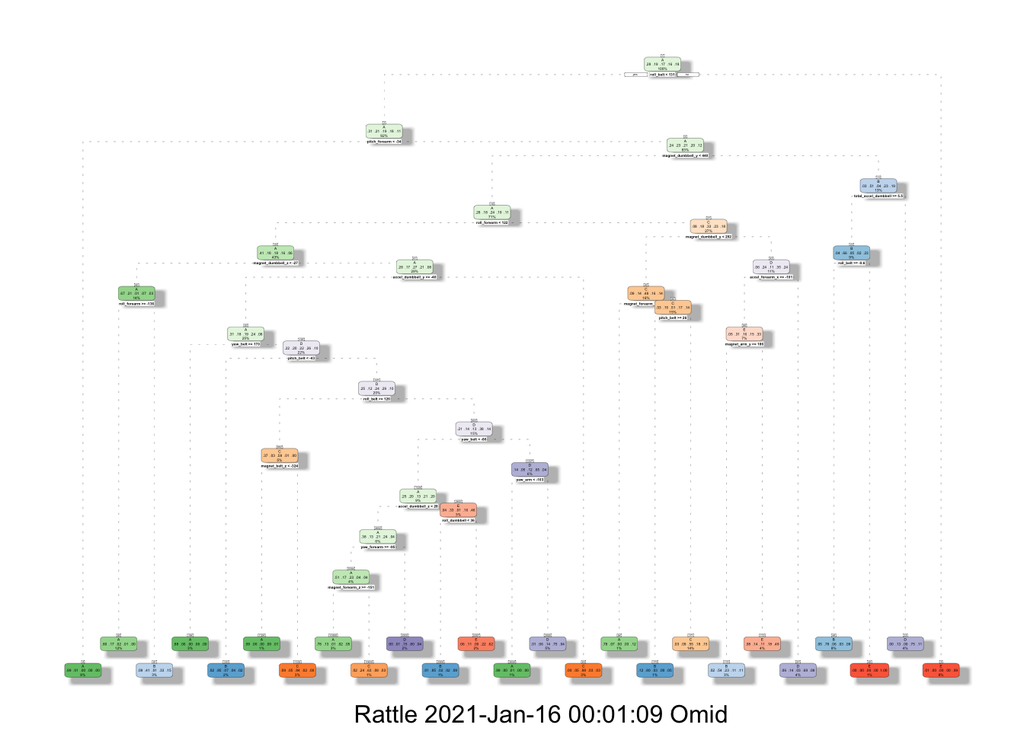

```r
set.seed(12345)
DecTreeMod <- rpart(classe ~ ., data=trainSet, method="class")
fancyRpartPlot(DecTreeMod)
```

We then validate the model using the testSet and assess its performance.

```r
PredTreeMod <- predict(DecTreeMod, testSet, type = "class")
cmtree <- confusionMatrix(PredTreeMod, testSet$classe)
cmtree
```

```
## Confusion Matrix and Statistics
##
##           Reference
## Prediction    A    B    C    D    E
##          A 1522  167   12   49   13
##          B   58  706  100   79   96
##          C   47  109  819  148  139
##          D   25   94   67  609   52
##          E   22   63   28   79  782
##
## Overall Statistics
##
##                Accuracy : 0.7541
##                  95% CI : (0.7429, 0.7651)
##     No Information Rate : 0.2845
##     P-Value [Acc > NIR] : < 2.2e-16
##
##                   Kappa : 0.6885
##
##  Mcnemar's Test P-Value : < 2.2e-16
##
## Statistics by Class:
##
##                      Class: A Class: B Class: C Class: D Class: E
## Sensitivity            0.9092   0.6198   0.7982   0.6317   0.7227
## Specificity            0.9428   0.9298   0.9088   0.9516   0.9600
## Pos Pred Value         0.8633   0.6795   0.6490   0.7190   0.8029
## Neg Pred Value         0.9631   0.9106   0.9552   0.9295   0.9389
## Prevalence             0.2845   0.1935   0.1743   0.1638   0.1839
## Detection Rate         0.2586   0.1200   0.1392   0.1035   0.1329
## Detection Prevalence   0.2996   0.1766   0.2144   0.1439   0.1655
## Balanced Accuracy      0.9260   0.7748   0.8535   0.7917   0.8414
```

We see that the accuracy rate of the model is 0.75; that is the the out of sample error is almost 0.25 which is significant.

### Prediction with Random Forest

For this algorithm, we first fit the model while using cross-validation for resampling.

```r
RFcontrol <- trainControl(method="cv", number=3, verboseIter=FALSE)
RFMod <- train(classe ~ ., data=trainSet, method="rf", trControl=RFcontrol)
RFMod$finalModel
```

```
##
## Call:
##  randomForest(x = x, y = y, mtry = param$mtry)
##                Type of random forest: classification
##                      Number of trees: 500
## No. of variables tried at each split: 27
##
##         OOB estimate of  error rate: 0.7%
## Confusion matrix:
##      A    B    C    D    E class.error
## A 3902    3    0    0    1 0.001024066
## B   19 2634    5    0    0 0.009029345
## C    0   17 2369   10    0 0.011268781
## D    0    1   26 2224    1 0.012433393
## E    0    2    5    6 2512 0.005148515
```

We then validate the model using the test set to find out how well it performs by looking at its accuracy.

```r
PredRF <- predict(RFMod, newdata=testSet)
RFcm <- confusionMatrix(PredRF, testSet$classe)
RFcm
```

```
## Confusion Matrix and Statistics
##
##           Reference
## Prediction    A    B    C    D    E
##          A 1673    5    0    0    0
##          B    0 1130   12    0    0
##          C    1    4 1011    9    0
##          D    0    0    3  954    0
##          E    0    0    0    1 1082
##
## Overall Statistics
##
##                Accuracy : 0.9941
##                  95% CI : (0.9917, 0.9959)
##     No Information Rate : 0.2845
##     P-Value [Acc > NIR] : < 2.2e-16
##
##                   Kappa : 0.9925
##
##  Mcnemar's Test P-Value : NA
##
## Statistics by Class:
##
##                      Class: A Class: B Class: C Class: D Class: E
## Sensitivity            0.9994   0.9921   0.9854   0.9896   1.0000
## Specificity            0.9988   0.9975   0.9971   0.9994   0.9998
## Pos Pred Value         0.9970   0.9895   0.9863   0.9969   0.9991
## Neg Pred Value         0.9998   0.9981   0.9969   0.9980   1.0000
## Prevalence             0.2845   0.1935   0.1743   0.1638   0.1839
## Detection Rate         0.2843   0.1920   0.1718   0.1621   0.1839
## Detection Prevalence   0.2851   0.1941   0.1742   0.1626   0.1840
## Balanced Accuracy      0.9991   0.9948   0.9912   0.9945   0.9999
```

The accuracy rate using random forest is 0.995; That is the out of sample error is 0.005. Note that this might be due to overfitting.

### Prediction with Generalized Boosted Model (GBM)

Finally, we use GBM and 5-fold cross-validation for resampling.

```r
set.seed(12345)
GBMcontrol <- trainControl(method = "repeatedcv", number = 5, repeats = 1)
GBMmod  <- train(classe ~ ., data=trainSet, method = "gbm", trControl = GBMcontrol, verbose = FALSE)
GBMmod$finalModel
```

```
## A gradient boosted model with multinomial loss function.
## 150 iterations were performed.
## There were 52 predictors of which 52 had non-zero influence.
```

```r
print(GBMmod)
```

```
## Stochastic Gradient Boosting
##
## 13737 samples
##    52 predictor
##     5 classes: 'A', 'B', 'C', 'D', 'E'
##
## No pre-processing
## Resampling: Cross-Validated (5 fold, repeated 1 times)
## Summary of sample sizes: 10990, 10990, 10989, 10991, 10988
## Resampling results across tuning parameters:
##
##   interaction.depth  n.trees  Accuracy   Kappa
##   1                   50      0.7521285  0.6858434
##   1                  100      0.8227397  0.7756753
##   1                  150      0.8521496  0.8129547
##   2                   50      0.8563724  0.8180344
##   2                  100      0.9059465  0.8809760
##   2                  150      0.9302623  0.9117412
##   3                   50      0.8969931  0.8695557
##   3                  100      0.9398712  0.9238994
##   3                  150      0.9593802  0.9486037
##
## Tuning parameter 'shrinkage' was held constant at a value of 0.1
##
## Tuning parameter 'n.minobsinnode' was held constant at a value of 10
## Accuracy was used to select the optimal model using the largest value.
## The final values used for the model were n.trees = 150, interaction.depth =
##  3, shrinkage = 0.1 and n.minobsinnode = 10.
```

Similarly, we validate and assess the perfomance of the GBM model.

```r
PredGBM <- predict(GBMmod, newdata=testSet)
GBMcm <- confusionMatrix(PredGBM, testSet$classe)
GBMcm
```

```
## Confusion Matrix and Statistics
##
##           Reference
## Prediction    A    B    C    D    E
##          A 1650   26    1    2    1
##          B   17 1091   35    3   12
##          C    5   20  979   26   11
##          D    1    2   11  928   10
##          E    1    0    0    5 1048
##
## Overall Statistics
##
##                Accuracy : 0.9679
##                  95% CI : (0.9631, 0.9722)
##     No Information Rate : 0.2845
##     P-Value [Acc > NIR] : < 2.2e-16
##
##                   Kappa : 0.9594
##
##  Mcnemar's Test P-Value : 1.749e-05
##
## Statistics by Class:
##
##                      Class: A Class: B Class: C Class: D Class: E
## Sensitivity            0.9857   0.9579   0.9542   0.9627   0.9686
## Specificity            0.9929   0.9859   0.9872   0.9951   0.9988
## Pos Pred Value         0.9821   0.9421   0.9404   0.9748   0.9943
## Neg Pred Value         0.9943   0.9898   0.9903   0.9927   0.9930
## Prevalence             0.2845   0.1935   0.1743   0.1638   0.1839
## Detection Rate         0.2804   0.1854   0.1664   0.1577   0.1781
## Detection Prevalence   0.2855   0.1968   0.1769   0.1618   0.1791
## Balanced Accuracy      0.9893   0.9719   0.9707   0.9789   0.9837
```

### Select the Best Model

Comparing the out of sample error of the three models, we select the Random Forest model for prediction of 20 cases of the testing data.

```r
FinalPred <- predict(RFMod, newdata=test)
FinalPred
```

```
##  [1] B A B A A E D B A A B C B A E E A B B B
## Levels: A B C D E
```